# CH2

Seongtaek

2023-03-29

# 데이터 시각화 실습 : 계절성 그래프 Figure 2.3, Figure 2.4

### - 패키지 불러오기

```r
library(ggplot2)
library(dplyr)
```

### - 파일 불러오기

- ncdc_normals.csv (날짜별 온도 등 데이터셋)

```r
ncdc_normals <- read.csv('C:/Users/seong taek/Desktop/3-1 DataVisualize/ncdc_normals.csv')
```

### - 불러온 데이터셋 파악

```r
# 차원 파악
ncdc_normals %>% dim()
```

```
#> [1] 2745366       6
```

```r
# 앞부분 훑어보기
ncdc_normals %>% head()
```

```
#>    station_id month day temperature flag       date
#> 1 AQW00061705     1   1        82.4    C 0000-01-01
#> 2 AQW00061705     1   2        82.4    C 0000-01-02
#> 3 AQW00061705     1   3        82.4    C 0000-01-03
#> 4 AQW00061705     1   4        82.4    C 0000-01-04
#> 5 AQW00061705     1   5        82.4    C 0000-01-05
#> 6 AQW00061705     1   6        82.4    C 0000-01-06
```

```r
# 통계 요약 정보
ncdc_normals %>% summary()
```

```
#>   station_id            month             day         temperature
#>  Length:2745366     Min.   : 1.000   Min.   : 1.00   Min.   :-21.80
#>  Class :character   1st Qu.: 4.000   1st Qu.: 8.00   1st Qu.: 39.70
#>  Mode  :character   Median : 7.000   Median :16.00   Median : 54.60
#>                     Mean   : 6.514   Mean   :15.76   Mean   : 53.17
#>                     3rd Qu.:10.000   3rd Qu.:23.00   3rd Qu.: 68.10
#>                     Max.   :12.000   Max.   :31.00   Max.   :103.20
#>      flag               date
#>  Length:2745366     Length:2745366
#>  Class :character   Class :character
#>  Mode  :character   Mode  :character
#>
#>
#>
```

```r
# 각 컬럼 클래스(타입) 확인
ncdc_normals %>% sapply(class)
```

```
#>  station_id       month         day temperature        flag        date
#> "character"   "integer"   "integer"   "numeric" "character" "character"
```

```r
# 각 컬럼 자료형 확인
ncdc_normals %>% sapply(typeof)
```

```
#>  station_id       month         day temperature        flag        date
#> "character"   "integer"   "integer"    "double" "character" "character"
```

### - character → date 형식 변환

```r
ncdc_normals$date <- ncdc_normals$date%>% as.Date("%Y-%m-%d")

ncdc_normals %>% sapply(class)
```

```
#>  station_id       month         day temperature        flag        date
#> "character"   "integer"   "integer"   "numeric" "character"      "Date"
```

```r
ncdc_normals %>% sapply(typeof)
```

```
#>  station_id       month         day temperature        flag        date
#> "character"   "integer"   "integer"    "double" "character"    "double"
```

### - station_id 종류 개수

```r
ncdc_normals$station_id %>% unique() %>% length()
```

```
#> [1] 7501
```

### - station_id 선정 후, location(컬럼 이름) 지정한 data.frame 생성

```r
station_loc <- data.frame(station_id = c("USW00014819","USC00042319","USW00093107","USW00012918"),
                          location = c("Chicago","Death Valley","San Diego","Houston"))
station_loc
```

```
#>    station_id     location
#> 1 USW00014819      Chicago
#> 2 USC00042319 Death Valley
#> 3 USW00093107    San Diego
#> 4 USW00012918      Houston
```

### - station_id로 ncdc_normals와 station_loc 두 컬럼을 `inner_join`

```r
temps_long <- ncdc_normals %>% inner_join(station_loc, by="station_id")

temps_long %>% head()
```

```
#>    station_id month day temperature flag       date     location
#> 1 USC00042319     1   1        51.0    S 0000-01-01 Death Valley
#> 2 USC00042319     1   2        51.2    S 0000-01-02 Death Valley
#> 3 USC00042319     1   3        51.3    S 0000-01-03 Death Valley
#> 4 USC00042319     1   4        51.4    S 0000-01-04 Death Valley
#> 5 USC00042319     1   5        51.6    S 0000-01-05 Death Valley
#> 6 USC00042319     1   6        51.7    S 0000-01-06 Death Valley
```

```r
temps_long %>% dim()
```

```
#> [1] 1464    7
```

```r
temps_long$date %>% class()
```

```
#> [1] "Date"
```

### - x축에 표시할 눈금 생성

```r
# x축 범위 설정을 위해 date 범위 파악
temps_long$date %>% head()
```

```
#> [1] "0000-01-01" "0000-01-02" "0000-01-03" "0000-01-04" "0000-01-05"
#> [6] "0000-01-06"
```

```r
temps_long$date %>% tail()
```

```
#> [1] "0000-12-26" "0000-12-27" "0000-12-28" "0000-12-29" "0000-12-30"
#> [6] "0000-12-31"
```

```r
# 범위 설정
date_s <- '0000-01-01' %>% as.Date('%Y-%m-%d')
date_e <- '0001-01-01' %>% as.Date('%Y-%m-%d')

# data_s ~ date_e까지 3개월 단위로 나누기
break_date <- seq(date_s, date_e, by = '3 month')

break_date
```

```
#> [1] "0000-01-01" "0000-04-01" "0000-07-01" "0000-10-01" "0001-01-01"
```

### - Fiqure 2.3 ggplot + 축 설정

- 사용 데이터셋 : temps_long
- x=date, y=temperature
- color : location별
- scale_x_date
  - 이름 : month
  - 간격 : break_date (3개월)
  - 간격 라벨 (Jan ~ Jan)
- scale_y_continuous
  - 이름 : temp
  - 범위 : 0 ~ 110
- labs : 제목, 부제목
- 테마 : 밝게

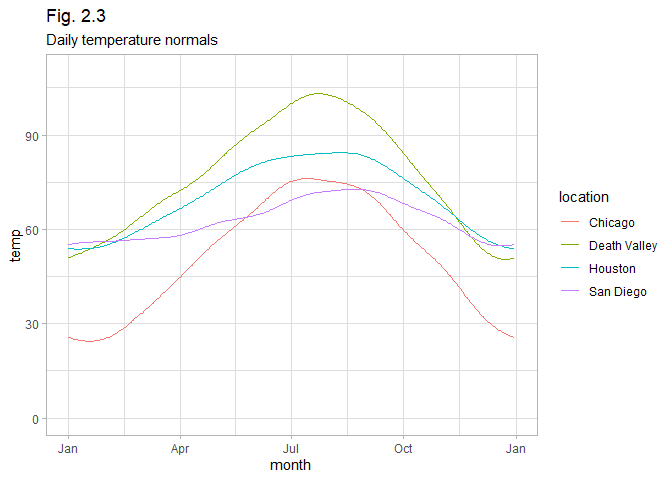

```r
ggplot(temps_long, aes(x=date, y=temperature, color=location)) +
  geom_line() +
  scale_x_date(name = 'month',
               breaks = break_date,
               labels = c('Jan','Apr','Jul','Oct','Jan')) +
  scale_y_continuous(name = 'temp', limits = c(0,110)) + # continuous 연속형 (온도)
  #ylab('Temp') +
  labs(title = 'Fig. 2.3', subtitle = 'Daily temperature normals') +
  theme_light()
```

### - Figure 2.4 그래프 데이터셋 전처리

```r
temps_long %>% head()
```

```
#>    station_id month day temperature flag       date     location
#> 1 USC00042319     1   1        51.0    S 0000-01-01 Death Valley
#> 2 USC00042319     1   2        51.2    S 0000-01-02 Death Valley
#> 3 USC00042319     1   3        51.3    S 0000-01-03 Death Valley
#> 4 USC00042319     1   4        51.4    S 0000-01-04 Death Valley
#> 5 USC00042319     1   5        51.6    S 0000-01-05 Death Valley
#> 6 USC00042319     1   6        51.7    S 0000-01-06 Death Valley
```

```r
temps_long %>% names()
```

```
#> [1] "station_id"  "month"       "day"         "temperature" "flag"
#> [6] "date"        "location"
```

```r
mean_temps <- temps_long %>%
  group_by(location, month) %>%           # location, month로 그룹화
  summarise(mean = mean(temperature)) %>% # 그룹화된 데이터의 집계값 요약
  ungroup() %>%                           # 그룹화를 해제하여 일반적인 데이터 프레임 형태로 사용
  mutate(month = factor(month %>%         # month값을 factor 형태로 수정해서 원하는 levels 지정가능
                          paste(), levels = 1:12 %>% paste()))
mean_temps
```

```
#> # A tibble: 48 × 3
#>    location month  mean
#>    <chr>    <fct> <dbl>
#>  1 Chicago  1      24.8
#>  2 Chicago  2      28.9
#>  3 Chicago  3      38.8
#>  4 Chicago  4      50.4
#>  5 Chicago  5      60.9
#>  6 Chicago  6      71.0
#>  7 Chicago  7      75.8
#>  8 Chicago  8      74.1
#>  9 Chicago  9      66.4
#> 10 Chicago  10     54.3
#> # … with 38 more rows
```

### - Figure 2.4 ggplot + geom_tile + fill color

- 사용 데이터셋 : mean_temps
- x=month, y=location
- fill : mean
- geom_tile : 넓이, 높이 지정
- scale_fill_viridis_c
  - 이름 : temperature
  - 옵션 : B (밝기)
  - begin, end : 색상의 시작,끝
- coord_fixed
  - expand = F : 공백 제거
- ylab(NULL) : y축 이름 제거

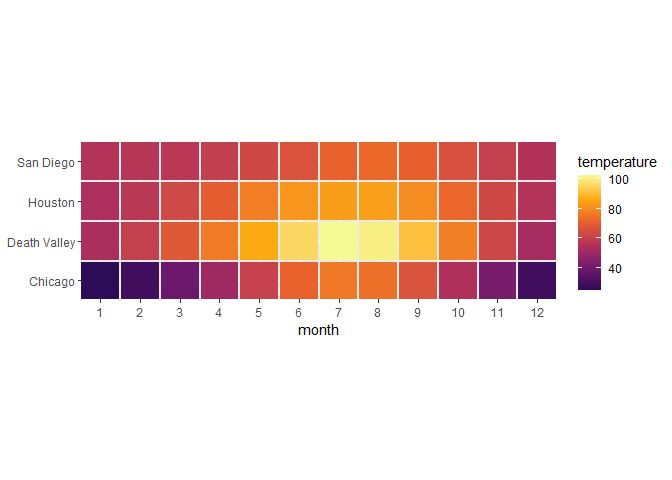

```r
ggplot(mean_temps, aes(x = month, y = location, fill = mean)) +
  geom_tile(width = .95, height = 0.95) +
  scale_fill_viridis_c(option = 'B', begin = 0.15, end =  0.98,
                       name = 'temperature') +
  coord_fixed(expand = FALSE) +
  ylab(NULL) #ylab('')
```

# 예제 : 2021년 기상청 자료 Figure 2.3, Figure 2.4

### - csv파일 불러오기, 데이터 파악

```r
data_2021 <- read.csv('C:/Users/seong taek/Desktop/3-1 DataVisualize/OBS_ASOS_DD_20220308125952.csv', fileEncoding = 'cp949')

data_2021 %>% dim()
```

```
#> [1] 1460    6
```

```r
data_2021 %>% head()
```

```
#>   지점 지점명       일시 평균기온..C. 최저기온..C. 최고기온..C.
#> 1  108   서울 2021-01-01         -4.2         -9.8          1.6
#> 2  108   서울 2021-01-02         -5.0         -8.4         -1.4
#> 3  108   서울 2021-01-03         -5.6         -9.1         -2.0
#> 4  108   서울 2021-01-04         -3.5         -8.4          0.3
#> 5  108   서울 2021-01-05         -5.5         -9.9         -2.1
#> 6  108   서울 2021-01-06         -7.4        -12.0         -1.9
```

```r
data_2021 %>% sapply(class)
```

```
#>         지점       지점명         일시 평균기온..C. 최저기온..C. 최고기온..C.
#>    "integer"  "character"  "character"    "numeric"    "numeric"    "numeric"
```

### - `일시`를 character → date형식으로 변환

```r
data_2021$일시 <- data_2021$일시 %>% as.Date('%Y-%m-%d')

data_2021 %>% sapply(class)
```

```
#>         지점       지점명         일시 평균기온..C. 최저기온..C. 최고기온..C.
#>    "integer"  "character"       "Date"    "numeric"    "numeric"    "numeric"
```

### - 기초통계량 파악

```r
data_2021 %>% summary()
```

```
#>       지점          지점명               일시             평균기온..C.
#>  Min.   :108.0   Length:1460        Min.   :2021-01-01   Min.   :-14.90
#>  1st Qu.:126.8   Class :character   1st Qu.:2021-04-02   1st Qu.:  7.90
#>  Median :158.5   Mode  :character   Median :2021-07-02   Median : 15.00
#>  Mean   :166.0                      Mean   :2021-07-02   Mean   : 14.77
#>  3rd Qu.:197.8                      3rd Qu.:2021-10-01   3rd Qu.: 23.10
#>  Max.   :239.0                      Max.   :2021-12-31   Max.   : 31.70
#>   최저기온..C.     최고기온..C.
#>  Min.   :-19.10   Min.   :-10.70
#>  1st Qu.:  3.10   1st Qu.: 13.18
#>  Median : 11.10   Median : 20.15
#>  Mean   : 10.69   Mean   : 19.56
#>  3rd Qu.: 19.60   3rd Qu.: 27.70
#>  Max.   : 28.10   Max.   : 36.50
```

### - x축에 표시할 눈금

```r
data_2021$일시 %>% head()
```

```
#> [1] "2021-01-01" "2021-01-02" "2021-01-03" "2021-01-04" "2021-01-05"
#> [6] "2021-01-06"
```

```r
data_2021$일시 %>% tail()
```

```
#> [1] "2021-12-26" "2021-12-27" "2021-12-28" "2021-12-29" "2021-12-30"
#> [6] "2021-12-31"
```

```r
date_s <- '2021-01-01' %>% as.Date('%Y-%m-%d')
date_e <- '2022-01-01' %>% as.Date('%Y-%m-%d')

break_date <- seq.Date(date_s, date_e, by='3 month')
break_date
```

```
#> [1] "2021-01-01" "2021-04-01" "2021-07-01" "2021-10-01" "2022-01-01"
```

```r
# 월만 문자 값으로 뽑아내기
date_lab <- format(break_date, '%B')
date_lab
```

```
#> [1] "1월"  "4월"  "7월"  "10월" "1월"
```

### - Figure 2.3 ggplot + 축 설정

- 사용 데이터셋 : data_2021
- x=일시, y=평균기온..C.
- color : 지점명 별
- scale_x_date
  - 이름 : 월
  - 간격 : break_date (3개월)
  - 간격 라벨 (1월 ~ 1월)
- scale_y_continuous
  - 이름 : 평균기온
- labs : 제목, 부제목
- 테마 : 밝게

```r
# 축 값 지정하기 전 컬럼이름 파악
data_2021 %>% names()
```

```
#> [1] "지점"         "지점명"       "일시"         "평균기온..C." "최저기온..C."
#> [6] "최고기온..C."
```

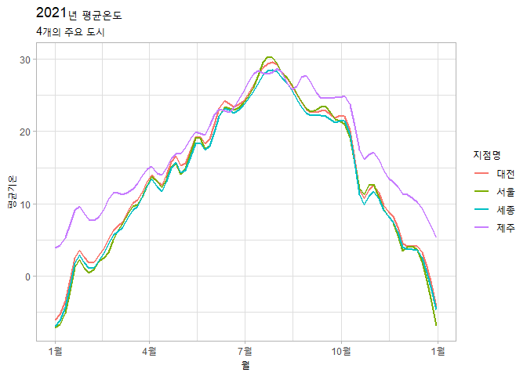

```r
ggplot(data_2021, aes(x=일시, y=평균기온..C., color=지점명)) +
  geom_smooth(linewidth = 0.9,se=F,span=0.1) + # linewidth (선 두께), geom_line → smooth 가능
  scale_x_date(name = '월',                  # se : 테두리, span : 스무스 정도
               breaks = break_date,
               labels = date_lab) +
  scale_y_continuous(name = '평균기온') +
  labs(title = '2021년 평균온도', subtitle = '4개의 주요 도시') +
  theme_light()
```

### - Figure 2.4 그래프 데이터셋 전처리

```r
data_2021 %>% names()
```

```
#> [1] "지점"         "지점명"       "일시"         "평균기온..C." "최저기온..C."
#> [6] "최고기온..C."
```

```r
data_2021 %>% head()
```

```
#>   지점 지점명       일시 평균기온..C. 최저기온..C. 최고기온..C.
#> 1  108   서울 2021-01-01         -4.2         -9.8          1.6
#> 2  108   서울 2021-01-02         -5.0         -8.4         -1.4
#> 3  108   서울 2021-01-03         -5.6         -9.1         -2.0
#> 4  108   서울 2021-01-04         -3.5         -8.4          0.3
#> 5  108   서울 2021-01-05         -5.5         -9.9         -2.1
#> 6  108   서울 2021-01-06         -7.4        -12.0         -1.9
```

```r
data_2021_month <- data_2021 %>%
  mutate(month = format(일시, '%B')) %>%   # 일시에서 월만 뽑아낸 month 컬럼 생성
  group_by(지점명, month) %>%              # 지점명, month로 그룹화
  summarise(mean = mean(평균기온..C.)) %>% # 그룹화된 데이터의 집계값 요약
  ungroup() %>%                            # 그룹화를 해제하여 일반적인 데이터 프레임 형태로 사용
  mutate(month = factor(month,             # month값을 factor 형태로 수정해서 원하는 levels 지정가능
                        levels = paste(1:12, '월',sep = ''))) # sep='' : 간격없이 붙이기
data_2021_month
```

```
#> # A tibble: 48 × 3
#>    지점명 month   mean
#>    <chr>  <fct>  <dbl>
#>  1 대전   10월  15.7
#>  2 대전   11월   8.91
#>  3 대전   12월   1.89
#>  4 대전   1월   -0.984
#>  5 대전   2월    3.99
#>  6 대전   3월    9.61
#>  7 대전   4월   14.7
#>  8 대전   5월   17.7
#>  9 대전   6월   23.5
#> 10 대전   7월   27.8
#> # … with 38 more rows
```

### - Figure 2.4 ggplot + geom_tile + fill color

- 사용 데이터셋 : data_2021_month
- x=month, y=지점명
- fill : mean(평균온도)
- geom_tile : 넓이, 높이 지정
- scale_fill_viridis_c
  - 이름 : temperature
  - 옵션 : B (밝기)
  - begin, end : 색상의 시작,끝
- coord_fixed
  - expand = F : 공백 제거
- ylab(NULL) : y축 이름 제거

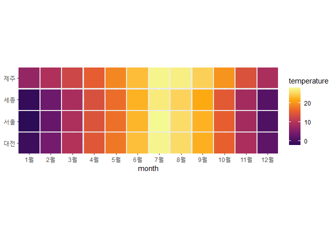

```r
ggplot(data_2021_month, aes(x = month, y = 지점명, fill = mean)) +
  geom_tile(width = 0.95, height = 0.95) +
  scale_fill_viridis_c(option = 'B', begin = 0.15, end =  0.98,
                       name = 'temperature') +
  coord_fixed(expand = FALSE) +
  ylab(NULL) #ylab('')
```

# 과제 : 2022년 기상청 자료 Figure 2.3, Figure 2.4

### - csv파일 불러오기, 데이터 파악

```r
data_2022 <- read.csv('C:/Users/seong taek/Desktop/3-1 DataVisualize/OBS_ASOS_DD_20230322080932.csv', fileEncoding = 'cp949')

data_2022 %>% dim()
```

```
#> [1] 2555    6
```

```r
data_2022 %>% head()
```

```
#>   지점 지점명       일시 평균기온..C. 최저기온..C. 최고기온..C.
#> 1  108   서울 2022-01-01         -4.3        -10.2          2.3
#> 2  108   서울 2022-01-02         -1.3         -5.2          3.0
#> 3  108   서울 2022-01-03         -1.9         -8.0          2.5
#> 4  108   서울 2022-01-04         -2.5         -5.6          1.0
#> 5  108   서울 2022-01-05         -2.8         -7.8          1.9
#> 6  108   서울 2022-01-06         -2.2         -5.9          3.3
```

```r
data_2022 %>% sapply(class)
```

```
#>         지점       지점명         일시 평균기온..C. 최저기온..C. 최고기온..C.
#>    "integer"  "character"  "character"    "numeric"    "numeric"    "numeric"
```

```r
# 결측값 있는지 확인
sum(is.na(data_2022))
```

```
#> [1] 4
```

```r
# 결측값 제거
data_2022 <- data_2022 %>% na.omit()
```

### - `일시`를 character → date형식으로 변환

```r
data_2022$일시 <- data_2022$일시 %>% as.Date('%Y-%m-%d')

data_2022 %>% sapply(class)
```

```
#>         지점       지점명         일시 평균기온..C. 최저기온..C. 최고기온..C.
#>    "integer"  "character"       "Date"    "numeric"    "numeric"    "numeric"
```

### - 기초통계량 파악

```r
data_2022 %>% summary()
```

```
#>       지점          지점명               일시             평균기온..C.
#>  Min.   :108.0   Length:2552        Min.   :2022-01-01   Min.   :-11.80
#>  1st Qu.:133.0   Class :character   1st Qu.:2022-04-02   1st Qu.:  8.20
#>  Median :185.0   Mode  :character   Median :2022-07-02   Median : 16.40
#>  Mean   :175.1                      Mean   :2022-07-01   Mean   : 15.26
#>  3rd Qu.:189.0                      3rd Qu.:2022-10-01   3rd Qu.: 23.00
#>  Max.   :239.0                      Max.   :2022-12-31   Max.   : 32.20
#>   최저기온..C.     최고기온..C.
#>  Min.   :-13.80   Min.   :-8.60
#>  1st Qu.:  4.20   1st Qu.:12.30
#>  Median : 12.60   Median :20.70
#>  Mean   : 11.62   Mean   :19.49
#>  3rd Qu.: 19.80   3rd Qu.:27.20
#>  Max.   : 28.90   Max.   :37.50
```

### - x축에 표시할 눈금

```r
data_2022$일시 %>% head()
```

```
#> [1] "2022-01-01" "2022-01-02" "2022-01-03" "2022-01-04" "2022-01-05"
#> [6] "2022-01-06"
```

```r
data_2022$일시 %>% tail()
```

```
#> [1] "2022-12-26" "2022-12-27" "2022-12-28" "2022-12-29" "2022-12-30"
#> [6] "2022-12-31"
```

```r
date_s <- '2022-01-01' %>% as.Date('%Y-%m-%d')
date_e <- '2023-01-01' %>% as.Date('%Y-%m-%d')

break_date <- seq.Date(date_s, date_e, by='3 month')
break_date
```

```
#> [1] "2022-01-01" "2022-04-01" "2022-07-01" "2022-10-01" "2023-01-01"
```

```r
# 월만 문자 값으로 뽑아내기
date_lab <- format(break_date, '%B')
date_lab
```

```
#> [1] "1월"  "4월"  "7월"  "10월" "1월"
```

### - Figure 2.3 ggplot + 축 설정

- 사용 데이터셋 : data_2022
- x=일시, y=평균기온..C.
- color : 지점명 별
- scale_x_date
  - 이름 : 월
  - 간격 : break_date (3개월)
  - 간격 라벨 (1월 ~ 1월)
- scale_y_continuous
  - 이름 : 평균기온
- labs : 제목, 부제목
- 테마 : 밝게

```r
# 축 값 지정하기 전 컬럼이름 파악
data_2022 %>% names()
```

```
#> [1] "지점"         "지점명"       "일시"         "평균기온..C." "최저기온..C."
#> [6] "최고기온..C."
```

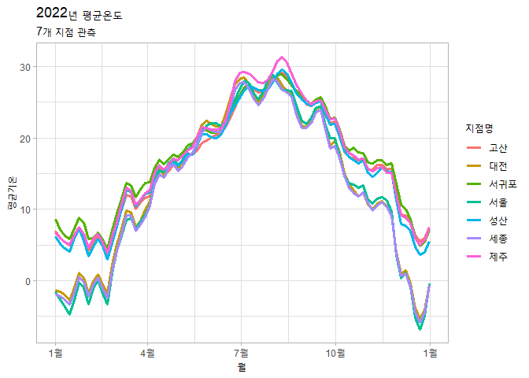

```r
ggplot(data_2022, aes(x=일시, y=평균기온..C., color=지점명)) +
  geom_smooth(linewidth = 1.1,se=F,span=0.08) + # linewidth (선 두께), geom_line → smooth 가능
  scale_x_date(name = '월',                  # se : 테두리, span : 스무스 정도
               breaks = break_date,
               labels = date_lab) +
  scale_y_continuous(name = '평균기온') +
  labs(title = '2022년 평균온도', subtitle = '7개 지점 관측') +
  theme_light()
```

### - Figure 2.4 그래프 데이터셋 전처리

```r
data_2022 %>% names()
```

```
#> [1] "지점"         "지점명"       "일시"         "평균기온..C." "최저기온..C."
#> [6] "최고기온..C."
```

```r
data_2022 %>% head()
```

```
#>   지점 지점명       일시 평균기온..C. 최저기온..C. 최고기온..C.
#> 1  108   서울 2022-01-01         -4.3        -10.2          2.3
#> 2  108   서울 2022-01-02         -1.3         -5.2          3.0
#> 3  108   서울 2022-01-03         -1.9         -8.0          2.5
#> 4  108   서울 2022-01-04         -2.5         -5.6          1.0
#> 5  108   서울 2022-01-05         -2.8         -7.8          1.9
#> 6  108   서울 2022-01-06         -2.2         -5.9          3.3
```

```r
data_2022_month <- data_2022 %>%
  mutate(month = format(일시, '%B')) %>%   # 일시에서 월만 뽑아낸 month 컬럼 생성
  group_by(지점명, month) %>%              # 지점명, month로 그룹화
  summarise(mean = mean(평균기온..C.)) %>% # 그룹화된 데이터의 집계값 요약
  ungroup() %>%                            # 그룹화를 해제하여 일반적인 데이터 프레임 형태로 사용
  mutate(month = factor(month,             # month값을 factor 형태로 수정해서 원하는 levels 지정가능
                        levels = paste(1:12, '월',sep = ''))) # sep='' : 간격없이 붙이기
data_2022_month
```

```
#> # A tibble: 84 × 3
#>    지점명 month  mean
#>    <chr>  <fct> <dbl>
#>  1 고산   10월  18.0
#>  2 고산   11월  15.5
#>  3 고산   12월   7.28
#>  4 고산   1월    6.08
#>  5 고산   2월    5.24
#>  6 고산   3월   10.8
#>  7 고산   4월   14.8
#>  8 고산   5월   18.1
#>  9 고산   6월   22.1
#> 10 고산   7월   27.0
#> # … with 74 more rows
```

### - Figure 2.4 ggplot + geom_tile + fill color

- 사용 데이터셋 : data_2022_month
- x=month, y=지점명
- fill : mean(평균온도)
- geom_tile : 넓이, 높이 지정
- scale_fill_viridis_c
  - 이름 : temperature
  - 옵션 : B (밝기)
  - begin, end : 색상의 시작,끝
- coord_fixed
  - expand = F : 공백 제거
- ylab(NULL) : y축 이름 제거

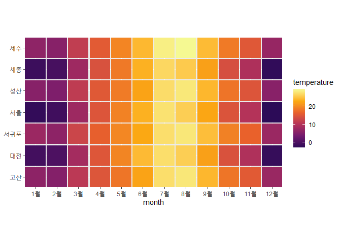

```r
ggplot(data_2022_month, aes(x = month, y = 지점명, fill = mean)) +
  geom_tile(width = 0.95, height = 0.95) +
  scale_fill_viridis_c(option = 'B', begin = 0.15, end =  0.98,
                       name = 'temperature') +
  coord_fixed(expand = FALSE) +
  ylab(NULL) #ylab('')
```